# work

Zhanbo Guo

2026-05-03

# Lab 7: ANOVA

## Introduction

This project practises ANOVA models in R. The aim is to compare group means across multiple groups and decide whether there are statistically significant differences.

## Files

- `Computer lab 7.1.R`: original R script for Exercise 1
- `data/`: dataset folder
- `output/`: output figures

## Load data

```r
fish <- read.csv("datas/fish1.csv", stringsAsFactors = T)
#stringsAsFactors = TRUE converts text columns into factors, which allows R to treat categorical variables as groups in statistical analyses.
str(fish)
```

```
## 'data.frame':    86 obs. of  2 variables:
##  $ weight: num  0.9 1.3 3.1 1.6 1.6 3.2 2 0.8 1.1 2.7 ...
##  $ Strain: Factor w/ 3 levels "Tilapia A","Tilapia B",..: 1 1 1 1 1 1 1 1 1 1 ...
```

```r
head(fish)
```

```
##   weight    Strain
## 1    0.9 Tilapia A
## 2    1.3 Tilapia A
## 3    3.1 Tilapia A
## 4    1.6 Tilapia A
## 5    1.6 Tilapia A
## 6    3.2 Tilapia A
```

## Boxplot of fish weight by strain

This code creates a boxplot of fish weight for each strain. It allows the distribution, median, spread and possible outliers of weight to be compared across different Tilapia strains.

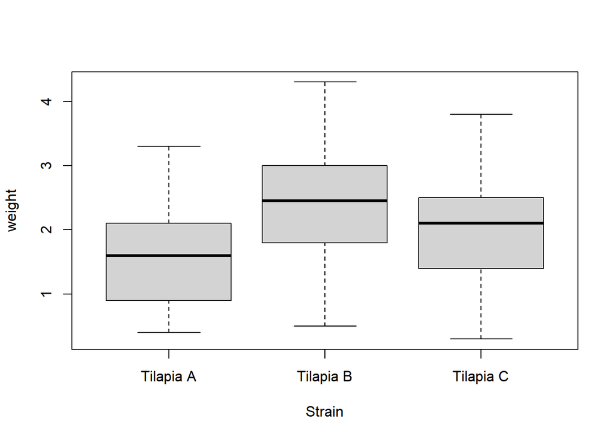

```r
with(fish, boxplot(weight ~ Strain))
```

## Edited boxplot

The boxplot was edited to improve readability. The x-axis and y-axis labels were added, the box width was reduced using `boxwex`, and the y-axis range was set from 0 to 5 using `ylim`.

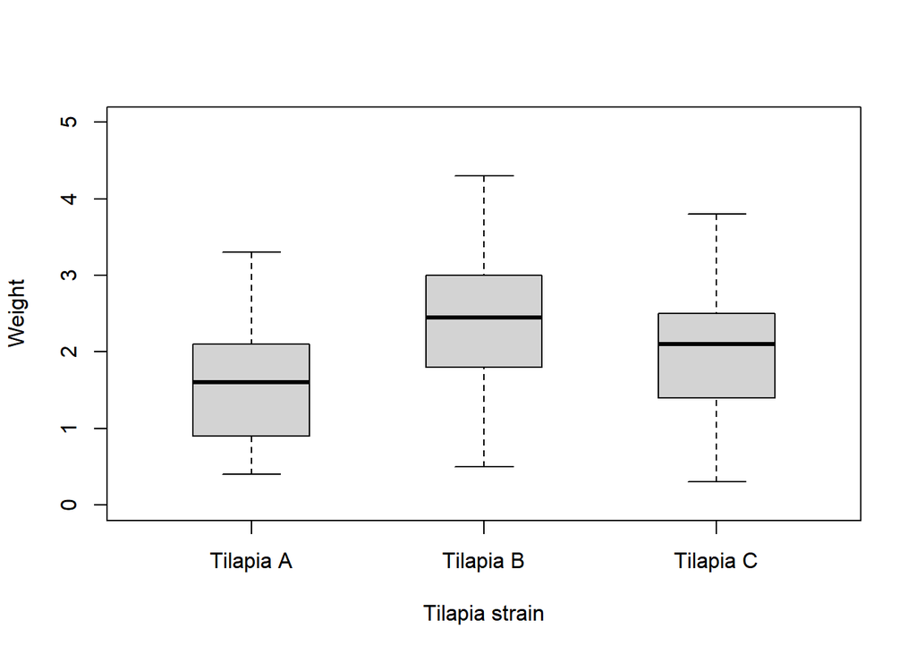

```r
# Create an edited boxplot with axis labels, thinner boxes, and a fixed y-axis range
with(fish, boxplot(weight ~ Strain,
                   xlab = "Tilapia strain",
                   ylab = "Weight",
                   boxwex = 0.5,
                   ylim = c(0, 5)))
```

## Test for equal group variances

Before conducting ANOVA, Bartlett’s test was used to test whether the variance of fish weight was equal across different Tilapia strains.

```r
with(fish, bartlett.test(weight ~ Strain))
```

```
##
##  Bartlett test of homogeneity of variances
##
## data:  weight by Strain
## Bartlett's K-squared = 0.50478, df = 2, p-value = 0.7769
```

Bartlett’s test showed no significant difference in variance among the three Tilapia strains, χ²(2) = 0.505, p = 0.777. Therefore, we do not reject the null hypothesis. This suggests that the assumption of equal group variance is reasonable, so a standard one-way ANOVA can be used.

## Pairwise t-tests

```r
with(fish, pairwise.t.test(weight, Strain, pool.sd = TRUE))
```

```
##
##  Pairwise comparisons using t tests with pooled SD
##
## data:  weight and Strain
##
##           Tilapia A Tilapia B
## Tilapia B 0.0041    -
## Tilapia C 0.1564    0.1564
##
## P value adjustment method: holm
```

## Result

The pairwise t-test table gives the adjusted p-values for each pairwise comparison between Tilapia strains.

The results suggest that:

- Strain A was significantly different from Strain B, with an adjusted p-value of 0.004.
- Strain A was not significantly different from Strain C, with an adjusted p-value of 0.16.
- Strain B was not significantly different from Strain C, with an adjusted p-value of 0.16.

Therefore, the only statistically significant pairwise difference was between Strain A and Strain B.